# 毎木調査データをDarwin Core Archiveで公開した話

## データ

- Core: Occurrence data
  - 個体（樹幹）を単位として測定しているので
- Extension: Measurement or Facts
  - 樹高または胸高直径

## データの内容

- 出現(occurrence)データ
- 測定(measurement)データ

| occurrenceID | catalogNumber | eventDate | scientificName | kingdom | phylum | class | order | family | genus | specificEpithet | infraspecificEpithet | taxonRank |
| --- | --- | --- | --- | --- | --- | --- | --- | --- | --- | --- | --- | --- |
| urn:catalog:FFPRI:Tomakomai1463:00001 | 1 | 2006-06-21/2011-09-21 | Fraxinus lanuginosa Koidz. f. serrata (Nakai) Murata | Plantae | Euphyllophytes | Magnoliopsida | Lamiales | Oleaceae | Fraxinus | lanuginosa | serrata | forma |
| urn:catalog:FFPRI:Tomakomai1463:00002 | 2 | 2006-06-20/2011-09-21 | Fraxinus lanuginosa Koidz. f. serrata (Nakai) Murata | Plantae | Euphyllophytes | Magnoliopsida | Lamiales | Oleaceae | Fraxinus | lanuginosa | serrata | forma |
| urn:catalog:FFPRI:Tomakomai1463:00003 | 3 | 2006-06-21/2011-09-21 | Fraxinus lanuginosa Koidz. f. serrata (Nakai) Murata | Plantae | Euphyllophytes | Magnoliopsida | Lamiales | Oleaceae | Fraxinus | lanuginosa | serrata | forma |
| urn:catalog:FFPRI:Tomakomai1463:00004 | 4 | 2006-06-21/2016-11-02 | Fraxinus lanuginosa Koidz. f. serrata (Nakai) Murata | Plantae | Euphyllophytes | Magnoliopsida | Lamiales | Oleaceae | Fraxinus | lanuginosa | serrata | forma |
| （中略） |  |  |  |  |  |  |  |  |  |  |  |  |
| urn:catalog:FFPRI:Tomakomai1463:03510 | 3510 | 2022-10-26/2022-10-26 | Abies sachalinensis (F.Schmidt) Mast. | Plantae | Euphyllophytes | Pinopsida | Pinales | Pinaceae | Abies | sachalinensis |  | species |
| urn:catalog:FFPRI:Tomakomai1463:03511 | 3511 | 2022-10-26/2022-10-26 | Abies sachalinensis (F.Schmidt) Mast. | Plantae | Euphyllophytes | Pinopsida | Pinales | Pinaceae | Abies | sachalinensis |  | species |

| CoreID | measurementID | measurementType | measurementValue | measurementAccuracy | measurementUnit | measurementDeterminedDate |
| --- | --- | --- | --- | --- | --- | --- |
| urn:catalog:FFPRI:Tomakomai1463:00001 | 8556 | Height | 18 | 1 | cm | 2006-06-21 |
| urn:catalog:FFPRI:Tomakomai1463:00001 | 9116 | Height | 31 | 1 | cm | 2011-09-21 |
| （中略） |  |  |  |  |  |  |
| urn:catalog:FFPRI:Tomakomai1463:00333 | 1012 | Height | 130 | 1 | cm | 1970-07 |
| urn:catalog:FFPRI:Tomakomai1463:00333 | 1013 | Diameter at Breast Height | 0.5 | 0.1 | cm | 1970-07 |
| （中略） |  |  |  |  |  |  |
| urn:catalog:FFPRI:Tomakomai1463:03510 | 12571 | Height | 10 | 1 | cm | 2022-10-26 |
| urn:catalog:FFPRI:Tomakomai1463:03511 | 12572 | Height | 11 | 1 | cm | 2022-10-26 |

# データの利用

## Rからの利用

1. 出現データと測定データをそれぞれ読み込んで、結合する。
2. 必要なデータを抽出してグラフを作成する。

## 出現データの読み込み

```r
(occ_data <- readr::read_tsv(occ_file))
```

```
# A tibble: 3,430 × 13
   occurre…¹ catal…² event…³ scien…⁴ kingdom phylum class order family genus
   <chr>       <dbl> <chr>   <chr>   <chr>   <chr>  <chr> <chr> <chr>  <chr>
 1 urn:cata…       1 2006-0… Fraxin… Plantae Euphy… Magn… Lami… Oleac… Frax…
 2 urn:cata…       2 2006-0… Fraxin… Plantae Euphy… Magn… Lami… Oleac… Frax…
 3 urn:cata…       3 2006-0… Fraxin… Plantae Euphy… Magn… Lami… Oleac… Frax…
 4 urn:cata…       4 2006-0… Fraxin… Plantae Euphy… Magn… Lami… Oleac… Frax…
 5 urn:cata…       5 2006-0… Fraxin… Plantae Euphy… Magn… Lami… Oleac… Frax…
 6 urn:cata…       6 2006-0… Fraxin… Plantae Euphy… Magn… Lami… Oleac… Frax…
 7 urn:cata…       7 2006-0… Fraxin… Plantae Euphy… Magn… Lami… Oleac… Frax…
 8 urn:cata…       8 2006-0… Fraxin… Plantae Euphy… Magn… Lami… Oleac… Frax…
 9 urn:cata…       9 2001-1… Fraxin… Plantae Euphy… Magn… Lami… Oleac… Frax…
10 urn:cata…      10 2006-0… Fraxin… Plantae Euphy… Magn… Lami… Oleac… Frax…
# … with 3,420 more rows, 3 more variables: specificEpithet <chr>,
#   infraspecificEpithet <chr>, taxonRank <chr>, and abbreviated variable
#   names ¹occurrenceID, ²catalogNumber, ³eventDate, ⁴scientificName
```

## 測定データの読み込み

```r
(mea_data <- readr::read_tsv(mea_file))
```

```
# A tibble: 12,558 × 7
   CoreID                    measu…¹ measu…² measu…³ measu…⁴ measu…⁵ measu…⁶
   <chr>                       <dbl> <chr>     <dbl>   <dbl> <chr>   <chr>
 1 urn:catalog:FFPRI:Tomako…    8556 Height       18       1 cm      2006-0…
 2 urn:catalog:FFPRI:Tomako…    9116 Height       31       1 cm      2011-0…
 3 urn:catalog:FFPRI:Tomako…    8557 Height       18       1 cm      2006-0…
 4 urn:catalog:FFPRI:Tomako…    9117 Height       29       1 cm      2011-0…
 5 urn:catalog:FFPRI:Tomako…    8558 Height       32       1 cm      2006-0…
 6 urn:catalog:FFPRI:Tomako…    9118 Height       26       1 cm      2011-0…
 7 urn:catalog:FFPRI:Tomako…    8559 Height       46       1 cm      2006-0…
 8 urn:catalog:FFPRI:Tomako…    9119 Height       25       1 cm      2011-0…
 9 urn:catalog:FFPRI:Tomako…   10195 Height       22       1 cm      2016-1…
10 urn:catalog:FFPRI:Tomako…    8560 Height       24       1 cm      2006-0…
# … with 12,548 more rows, and abbreviated variable names ¹measurementID,
#   ²measurementType, ³measurementValue, ⁴measurementAccuracy,
#   ⁵measurementUnit, ⁶measurementDeterminedDate
```

## データの結合と整理

各樹幹について各年の樹高データを抽出する。

```r
height_data <-
  # 測定データに出現データを結合
  dplyr::left_join(mea_data, occ_data,
                   by = c("CoreID" = "occurrenceID")) %>%
  # 必要な項目を抽出
  dplyr::transmute(catalogNumber,
                   Species = str_c(genus, " ", specificEpithet),
                   measurementType, measurementValue,
                   Year = str_sub(measurementDeterminedDate, 1, 4) %>%
                          as.integer()) %>%
  # 不明種を除去し、樹高データを抽出
  dplyr::filter(!is.na(Species),
                measurementType == "Height") %>%
  # 2016年データの一部は2017年に測定したので統合
  dplyr::mutate(Year = if_else(Year == 2017L, 2016L, Year))
```

```r
print(height_data)
```

```
# A tibble: 8,893 × 5
   catalogNumber Species             measurementType measurementValue  Year
           <dbl> <chr>               <chr>                      <dbl> <int>
 1             1 Fraxinus lanuginosa Height                        18  2006
 2             1 Fraxinus lanuginosa Height                        31  2011
 3             2 Fraxinus lanuginosa Height                        18  2006
 4             2 Fraxinus lanuginosa Height                        29  2011
 5             3 Fraxinus lanuginosa Height                        32  2006
 6             3 Fraxinus lanuginosa Height                        26  2011
 7             4 Fraxinus lanuginosa Height                        46  2006
 8             4 Fraxinus lanuginosa Height                        25  2011
 9             4 Fraxinus lanuginosa Height                        22  2016
10             5 Fraxinus lanuginosa Height                        24  2006
# … with 8,883 more rows
```

## グラフ表示

エゾマツとトドマツの最大樹高をプロット

```r
plot_max_height <- height_data %>%
  # エゾマツとトドマツを抽出
  dplyr::filter(Species %in% c("Picea jezoensis",
                               "Abies sachalinensis")) %>%
  # 樹種と測定年でグループ化
  dplyr::group_by(Species, Year) %>%
  # 樹種・測定年ごとの最大樹高(m)を求める
  dplyr::summarise(Max_height = max(measurementValue, na.rm = TRUE) / 100,
                   .groups = "drop") %>%
  ggplot(aes(x = Year, y = Max_height, colour = Species)) +
  geom_line(size = 2) +
  ylim(0, NA) + labs(y = "Max height (m)") +
  theme_grey(base_size = 14)
```

```r
print(plot_max_height)
```

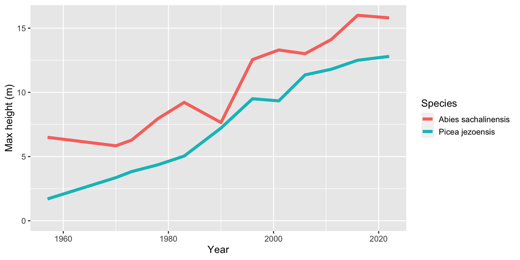

# おわりに

- 生態学データ（毎木調査・個体数データなど）は、研究室での入力・保管フォーマットはさまざま
- Darwin Core Archiveとして出力することで、共通フォーマットとして利用可能

## 参考文献

- Itô et al. (2018) Ecological Research 33: 283–283. doi:10.1007/s11284-018-1559-3
- 大澤・戸津 (2017) 保全生態学研究 22:371–381 doi:10.18960/hozen.22.2_371